# CDI weight

## 2026 Correlation Analysis

```r
#==========================
# Pearson Correlations
#==========================

with(CDI_outcomes_2025_2026,
     cor.test(elite_index, pb_xRV100_2026,
              method = "pearson"))
```

```
##
##  Pearson's product-moment correlation
##
## data:  elite_index and pb_xRV100_2026
## t = -9.1392, df = 395, p-value < 2.2e-16
## alternative hypothesis: true correlation is not equal to 0
## 95 percent confidence interval:
##  -0.4958217 -0.3330612
## sample estimates:
##        cor
## -0.4177878
```

```r
with(CDI_outcomes_2025_2026,
     cor.test(elite_index, SIERA_2026,
              method = "pearson"))
```

```
##
##  Pearson's product-moment correlation
##
## data:  elite_index and SIERA_2026
## t = -8.0411, df = 394, p-value = 1.052e-14
## alternative hypothesis: true correlation is not equal to 0
## 95 percent confidence interval:
##  -0.4570981 -0.2875584
## sample estimates:
##        cor
## -0.3754648
```

```r
with(CDI_outcomes_2025_2026,
     cor.test(elite_index, xERA_2026,
              method = "pearson"))
```

```
##
##  Pearson's product-moment correlation
##
## data:  elite_index and xERA_2026
## t = -4.9554, df = 395, p-value = 1.073e-06
## alternative hypothesis: true correlation is not equal to 0
## 95 percent confidence interval:
##  -0.3324329 -0.1470050
## sample estimates:
##        cor
## -0.2419265
```

```r
with(CDI_outcomes_2025_2026,
     cor.test(elite_index, FIP_2026,
              method = "pearson"))
```

```
##
##  Pearson's product-moment correlation
##
## data:  elite_index and FIP_2026
## t = -3.9262, df = 395, p-value = 0.0001018
## alternative hypothesis: true correlation is not equal to 0
## 95 percent confidence interval:
##  -0.28675321 -0.09723368
## sample estimates:
##        cor
## -0.1938009
```

```r
with(CDI_outcomes_2025_2026,
     cor.test(elite_index, xFIP_2026,
              method = "pearson"))
```

```
##
##  Pearson's product-moment correlation
##
## data:  elite_index and xFIP_2026
## t = -4.8507, df = 395, p-value = 1.773e-06
## alternative hypothesis: true correlation is not equal to 0
## 95 percent confidence interval:
##  -0.3278755 -0.1419968
## sample estimates:
##       cor
## -0.237105
```

```r
with(CDI_outcomes_2025_2026,
     cor.test(elite_index, ERA_2026,
              method = "pearson"))
```

```
##
##  Pearson's product-moment correlation
##
## data:  elite_index and ERA_2026
## t = -2.0035, df = 395, p-value = 0.0458
## alternative hypothesis: true correlation is not equal to 0
## 95 percent confidence interval:
##  -0.19677976 -0.00189725
## sample estimates:
##        cor
## -0.1003004
```

```r
with(CDI_outcomes_2025_2026,
     cor.test(elite_index, RA9_Wins_2026,
              method = "pearson"))
```

```
##
##  Pearson's product-moment correlation
##
## data:  elite_index and RA9_Wins_2026
## t = 4.1323, df = 395, p-value = 4.387e-05
## alternative hypothesis: true correlation is not equal to 0
## 95 percent confidence interval:
##  0.1072922 0.2960548
## sample estimates:
##       cor
## 0.2035644
```

```r
#==========================
# Spearman Correlations
#==========================

with(CDI_outcomes_2025_2026,
     cor.test(elite_index, pb_xRV100_2026,
              method = "spearman"))
```

```
##
##  Spearman's rank correlation rho
##
## data:  elite_index and pb_xRV100_2026
## S = 15150093, p-value < 2.2e-16
## alternative hypothesis: true rho is not equal to 0
## sample estimates:
##        rho
## -0.4527731
```

```r
with(CDI_outcomes_2025_2026,
     cor.test(elite_index, SIERA_2026,
              method = "spearman"))
```

```
##
##  Spearman's rank correlation rho
##
## data:  elite_index and SIERA_2026
## S = 14741543, p-value < 2.2e-16
## alternative hypothesis: true rho is not equal to 0
## sample estimates:
##        rho
## -0.4243326
```

```r
with(CDI_outcomes_2025_2026,
     cor.test(elite_index, xERA_2026,
              method = "spearman"))
```

```
##
##  Spearman's rank correlation rho
##
## data:  elite_index and xERA_2026
## S = 14910146, p-value < 2.2e-16
## alternative hypothesis: true rho is not equal to 0
## sample estimates:
##        rho
## -0.4297641
```

```r
with(CDI_outcomes_2025_2026,
     cor.test(elite_index, FIP_2026,
              method = "spearman"))
```

```
##
##  Spearman's rank correlation rho
##
## data:  elite_index and FIP_2026
## S = 14387770, p-value = 4.636e-15
## alternative hypothesis: true rho is not equal to 0
## sample estimates:
##        rho
## -0.3796724
```

```r
with(CDI_outcomes_2025_2026,
     cor.test(elite_index, xFIP_2026,
              method = "spearman"))
```

```
##
##  Spearman's rank correlation rho
##
## data:  elite_index and xFIP_2026
## S = 14241184, p-value = 5.315e-14
## alternative hypothesis: true rho is not equal to 0
## sample estimates:
##        rho
## -0.3656159
```

```r
with(CDI_outcomes_2025_2026,
     cor.test(elite_index, ERA_2026,
              method = "spearman"))
```

```
##
##  Spearman's rank correlation rho
##
## data:  elite_index and ERA_2026
## S = 13563386, p-value = 9.784e-10
## alternative hypothesis: true rho is not equal to 0
## sample estimates:
##        rho
## -0.3006206
```

```r
with(CDI_outcomes_2025_2026,
     cor.test(elite_index, RA9_Wins_2026,
              method = "spearman"))
```

```
##
##  Spearman's rank correlation rho
##
## data:  elite_index and RA9_Wins_2026
## S = 8396995, p-value = 9.364e-05
## alternative hypothesis: true rho is not equal to 0
## sample estimates:
##       rho
## 0.1947952
```

```r
library(dplyr)
library(knitr)
library(kableExtra)
correlation_table_2026 <- tibble(
  Outcome = c(
    "PitchBot xRV100",
    "SIERA",
    "xERA",
    "FIP",
    "xFIP",
    "ERA",
    "RA9-Wins"
  ),

  Pearson_r = c(
    -0.4177878,
    -0.3754648,
    -0.2419265,
    -0.1938009,
    -0.2371050,
    -0.1003004,
     0.2035644
  ),

  Pearson_p = c(
    "< .001",
    "< .001",
    "< .001",
    "< .001",
    "< .001",
    ".046",
    "< .001"
  ),

  Spearman_rho = c(
    -0.4527731,
    -0.4243326,
    -0.4297641,
    -0.3796724,
    -0.3656159,
    -0.3006206,
     0.1947952
  ),

  Spearman_p = c(
    "< .001",
    "< .001",
    "< .001",
    "< .001",
    "< .001",
    "< .001",
    "< .001"
  ),

  Interpretation = c(
    "Strongest predictive relationship",
    "Strong prediction of underlying skill",
    "Moderate rank prediction",
    "Modest linear, moderate rank relationship",
    "Modest-to-moderate prediction",
    "Weak linear, meaningful rank prediction",
    "Small positive relationship with future value"
  )
)

correlation_table_2026 %>%
  mutate(
    Pearson_r = round(Pearson_r, 3),
    Spearman_rho = round(Spearman_rho, 3)
  ) %>%
  kable(
    caption = "Predictive Validity of 2025 CDI for 2026 Pitching Outcomes",
    col.names = c(
      "2026 Outcome",
      "Pearson r",
      "Pearson p",
      "Spearman rho",
      "Spearman p",
      "Interpretation"
    ),
    align = c("l", "c", "c", "c", "c", "l"),
    booktabs = TRUE
  ) %>%
  kable_styling(
    full_width = FALSE,
    position = "center",
    bootstrap_options = c("striped", "hover", "condensed")
  )
```

Predictive Validity of 2025 CDI for 2026 Pitching Outcomes

| 2026 Outcome | Pearson r | Pearson p | Spearman rho | Spearman p | Interpretation |
| --- | --- | --- | --- | --- | --- |
| PitchBot xRV100 | -0.418 | < .001 | -0.453 | < .001 | Strongest predictive relationship |
| SIERA | -0.375 | < .001 | -0.424 | < .001 | Strong prediction of underlying skill |
| xERA | -0.242 | < .001 | -0.430 | < .001 | Moderate rank prediction |
| FIP | -0.194 | < .001 | -0.380 | < .001 | Modest linear, moderate rank relationship |
| xFIP | -0.237 | < .001 | -0.366 | < .001 | Modest-to-moderate prediction |
| ERA | -0.100 | .046 | -0.301 | < .001 | Weak linear, meaningful rank prediction |
| RA9-Wins | 0.204 | < .001 | 0.195 | < .001 | Small positive relationship with future value |

## Linear Regression

```r
# PitchBot expected run value
lm_pb_xRV100_2026 <- lm(
  pb_xRV100_2026 ~ elite_index,
  data = CDI_outcomes_2025_2026
)

summary(lm_pb_xRV100_2026)
```

```
##
## Call:
## lm(formula = pb_xRV100_2026 ~ elite_index, data = CDI_outcomes_2025_2026)
##
## Residuals:
##     Min      1Q  Median      3Q     Max
## -1.2507 -0.3194 -0.0494  0.2481  4.7957
##
## Coefficients:
##             Estimate Std. Error t value Pr(>|t|)
## (Intercept)  0.08159    0.02766   2.949  0.00338 **
## elite_index -0.38639    0.04228  -9.139  < 2e-16 ***
## ---
## Signif. codes:  0 '***' 0.001 '**' 0.01 '*' 0.05 '.' 0.1 ' ' 1
##
## Residual standard error: 0.5492 on 395 degrees of freedom
##   (77 observations deleted due to missingness)
## Multiple R-squared:  0.1745, Adjusted R-squared:  0.1725
## F-statistic: 83.52 on 1 and 395 DF,  p-value: < 2.2e-16
```

```r
# SIERA
lm_SIERA_2026 <- lm(
  SIERA_2026 ~ elite_index,
  data = CDI_outcomes_2025_2026
)

summary(lm_SIERA_2026)
```

```
##
## Call:
## lm(formula = SIERA_2026 ~ elite_index, data = CDI_outcomes_2025_2026)
##
## Residuals:
##     Min      1Q  Median      3Q     Max
## -2.0589 -0.5815 -0.0592  0.4294  6.9330
##
## Coefficients:
##             Estimate Std. Error t value Pr(>|t|)
## (Intercept)  4.24217    0.04868  87.148  < 2e-16 ***
## elite_index -0.59845    0.07442  -8.041 1.05e-14 ***
## ---
## Signif. codes:  0 '***' 0.001 '**' 0.01 '*' 0.05 '.' 0.1 ' ' 1
##
## Residual standard error: 0.9649 on 394 degrees of freedom
##   (78 observations deleted due to missingness)
## Multiple R-squared:  0.141,  Adjusted R-squared:  0.1388
## F-statistic: 64.66 on 1 and 394 DF,  p-value: 1.052e-14
```

```r
# xERA
lm_xERA_2026 <- lm(
  xERA_2026 ~ elite_index,
  data = CDI_outcomes_2025_2026
)

summary(lm_xERA_2026)
```

```
##
## Call:
## lm(formula = xERA_2026 ~ elite_index, data = CDI_outcomes_2025_2026)
##
## Residuals:
##    Min     1Q Median     3Q    Max
## -3.517 -1.124 -0.525  0.338 41.246
##
## Coefficients:
##             Estimate Std. Error t value Pr(>|t|)
## (Intercept)   4.8574     0.1622  29.948  < 2e-16 ***
## elite_index  -1.2283     0.2479  -4.955 1.07e-06 ***
## ---
## Signif. codes:  0 '***' 0.001 '**' 0.01 '*' 0.05 '.' 0.1 ' ' 1
##
## Residual standard error: 3.22 on 395 degrees of freedom
##   (77 observations deleted due to missingness)
## Multiple R-squared:  0.05853,    Adjusted R-squared:  0.05614
## F-statistic: 24.56 on 1 and 395 DF,  p-value: 1.073e-06
```

```r
# FIP
lm_FIP_2026 <- lm(
  FIP_2026 ~ elite_index,
  data = CDI_outcomes_2025_2026
)

summary(lm_FIP_2026)
```

```
##
## Call:
## lm(formula = FIP_2026 ~ elite_index, data = CDI_outcomes_2025_2026)
##
## Residuals:
##    Min     1Q Median     3Q    Max
## -3.545 -1.201 -0.636  0.391 55.167
##
## Coefficients:
##             Estimate Std. Error t value Pr(>|t|)
## (Intercept)   4.8411     0.1731  27.971  < 2e-16 ***
## elite_index  -1.0385     0.2645  -3.926 0.000102 ***
## ---
## Signif. codes:  0 '***' 0.001 '**' 0.01 '*' 0.05 '.' 0.1 ' ' 1
##
## Residual standard error: 3.436 on 395 degrees of freedom
##   (77 observations deleted due to missingness)
## Multiple R-squared:  0.03756,    Adjusted R-squared:  0.03512
## F-statistic: 15.41 on 1 and 395 DF,  p-value: 0.0001018
```

```r
# xFIP
lm_xFIP_2026 <- lm(
  xFIP_2026 ~ elite_index,
  data = CDI_outcomes_2025_2026
)

summary(lm_xFIP_2026)
```

```
##
## Call:
## lm(formula = xFIP_2026 ~ elite_index, data = CDI_outcomes_2025_2026)
##
## Residuals:
##     Min      1Q  Median      3Q     Max
## -3.2078 -0.7620 -0.2553  0.3959 25.8171
##
## Coefficients:
##             Estimate Std. Error t value Pr(>|t|)
## (Intercept)   4.4938     0.0853  52.684  < 2e-16 ***
## elite_index  -0.6323     0.1304  -4.851 1.77e-06 ***
## ---
## Signif. codes:  0 '***' 0.001 '**' 0.01 '*' 0.05 '.' 0.1 ' ' 1
##
## Residual standard error: 1.693 on 395 degrees of freedom
##   (77 observations deleted due to missingness)
## Multiple R-squared:  0.05622,    Adjusted R-squared:  0.05383
## F-statistic: 23.53 on 1 and 395 DF,  p-value: 1.773e-06
```

```r
# ERA
lm_ERA_2026 <- lm(
  ERA_2026 ~ elite_index,
  data = CDI_outcomes_2025_2026
)

summary(lm_ERA_2026)
```

```
##
## Call:
## lm(formula = ERA_2026 ~ elite_index, data = CDI_outcomes_2025_2026)
##
## Residuals:
##     Min      1Q  Median      3Q     Max
##  -6.622  -2.068  -1.050   0.049 156.399
##
## Coefficients:
##             Estimate Std. Error t value Pr(>|t|)
## (Intercept)   5.4755     0.4398  12.449   <2e-16 ***
## elite_index  -1.3468     0.6722  -2.004   0.0458 *
## ---
## Signif. codes:  0 '***' 0.001 '**' 0.01 '*' 0.05 '.' 0.1 ' ' 1
##
## Residual standard error: 8.732 on 395 degrees of freedom
##   (77 observations deleted due to missingness)
## Multiple R-squared:  0.01006,    Adjusted R-squared:  0.007554
## F-statistic: 4.014 on 1 and 395 DF,  p-value: 0.0458
```

```r
# RA9-Wins
lm_RA9_Wins_2026 <- lm(
  RA9_Wins_2026 ~ elite_index,
  data = CDI_outcomes_2025_2026
)

summary(lm_RA9_Wins_2026)
```

```
##
## Call:
## lm(formula = RA9_Wins_2026 ~ elite_index, data = CDI_outcomes_2025_2026)
##
## Residuals:
##     Min      1Q  Median      3Q     Max
## -2.3182 -0.7777 -0.2661  0.4399  3.8896
##
## Coefficients:
##             Estimate Std. Error t value Pr(>|t|)
## (Intercept)  0.57144    0.05729   9.975  < 2e-16 ***
## elite_index  0.36179    0.08755   4.132 4.39e-05 ***
## ---
## Signif. codes:  0 '***' 0.001 '**' 0.01 '*' 0.05 '.' 0.1 ' ' 1
##
## Residual standard error: 1.137 on 395 degrees of freedom
##   (77 observations deleted due to missingness)
## Multiple R-squared:  0.04144,    Adjusted R-squared:  0.03901
## F-statistic: 17.08 on 1 and 395 DF,  p-value: 4.387e-05
```

```r
library(dplyr)
library(knitr)
library(kableExtra)

regression_table <- tibble(
  Outcome = c(
    "PitchBot xRV100",
    "SIERA",
    "xERA",
    "xFIP",
    "RA9-Wins",
    "FIP",
    "ERA"
  ),

  Beta = c(
    -0.38639,
    -0.59845,
    -1.22830,
    -0.63230,
     0.36179,
    -1.03850,
    -1.34680
  ),

  Adj_R2 = c(
    0.1725,
    0.1388,
    0.0561,
    0.0538,
    0.0390,
    0.0351,
    0.0076
  ),

  p_value = c(
    "< .001",
    "< .001",
    "< .001",
    "< .001",
    "< .001",
    "< .001",
    ".046"
  ),

  Interpretation = c(
    "Strongest predictive model",
    "Strong prediction of future skill",
    "Modest prediction",
    "Modest prediction",
    "Small positive relationship",
    "Small but significant prediction",
    "Weak prediction"
  )
)

regression_table %>%
  mutate(
    Beta = round(Beta, 3),
    Adj_R2 = round(Adj_R2, 3)
  ) %>%
  kable(
    caption = "Simple Linear Regression Models Predicting 2026 Performance from the 2025 Composite Dominance Index (CDI)",
    col.names = c(
      "2026 Outcome",
      expression(beta),
      "Adjusted R²",
      "p-value",
      "Interpretation"
    ),
    align = c("l","c","c","c","l"),
    booktabs = TRUE
  ) %>%
  kable_styling(
    full_width = FALSE,
    position = "center",
    bootstrap_options = c("striped","hover","condensed")
  )
```

Simple Linear Regression Models Predicting 2026 Performance from the 2025 Composite Dominance Index (CDI)

| 2026 Outcome | beta | Adjusted R² | p-value | Interpretation |
| --- | --- | --- | --- | --- |
| PitchBot xRV100 | -0.386 | 0.172 | < .001 | Strongest predictive model |
| SIERA | -0.598 | 0.139 | < .001 | Strong prediction of future skill |
| xERA | -1.228 | 0.056 | < .001 | Modest prediction |
| xFIP | -0.632 | 0.054 | < .001 | Modest prediction |
| RA9-Wins | 0.362 | 0.039 | < .001 | Small positive relationship |
| FIP | -1.038 | 0.035 | < .001 | Small but significant prediction |
| ERA | -1.347 | 0.008 | .046 | Weak prediction |

## Multiple Linear Regression

```r
# PitchBot expected run value
skills_pb_xRV100_2026 <- lm(
  pb_xRV100_2026 ~ z_stuff + z_command + z_miss + z_contact,
  data = CDI_outcomes_2025_2026
)

summary(skills_pb_xRV100_2026)
```

```
##
## Call:
## lm(formula = pb_xRV100_2026 ~ z_stuff + z_command + z_miss +
##     z_contact, data = CDI_outcomes_2025_2026)
##
## Residuals:
##     Min      1Q  Median      3Q     Max
## -1.2420 -0.3082 -0.0324  0.2133  4.8915
##
## Coefficients:
##             Estimate Std. Error t value Pr(>|t|)
## (Intercept)  0.08270    0.02746   3.012 0.002766 **
## z_stuff     -0.20905    0.03721  -5.618 3.66e-08 ***
## z_command   -0.09698    0.02821  -3.438 0.000649 ***
## z_miss      -0.01728    0.03481  -0.496 0.619952
## z_contact   -0.03219    0.03084  -1.044 0.297228
## ---
## Signif. codes:  0 '***' 0.001 '**' 0.01 '*' 0.05 '.' 0.1 ' ' 1
##
## Residual standard error: 0.5451 on 392 degrees of freedom
##   (77 observations deleted due to missingness)
## Multiple R-squared:  0.1931, Adjusted R-squared:  0.1849
## F-statistic: 23.45 on 4 and 392 DF,  p-value: < 2.2e-16
```

```r
# SIERA
skills_SIERA_2026 <- lm(
  SIERA_2026 ~ z_stuff + z_command + z_miss + z_contact,
  data = CDI_outcomes_2025_2026
)

summary(skills_SIERA_2026)
```

```
##
## Call:
## lm(formula = SIERA_2026 ~ z_stuff + z_command + z_miss + z_contact,
##     data = CDI_outcomes_2025_2026)
##
## Residuals:
##     Min      1Q  Median      3Q     Max
## -2.1633 -0.6112 -0.0702  0.4102  6.7092
##
## Coefficients:
##              Estimate Std. Error t value Pr(>|t|)
## (Intercept)  4.240640   0.048078  88.203  < 2e-16 ***
## z_stuff     -0.273243   0.065069  -4.199 3.32e-05 ***
## z_command   -0.001891   0.049320  -0.038  0.96943
## z_miss      -0.167597   0.060962  -2.749  0.00625 **
## z_contact   -0.064515   0.053976  -1.195  0.23272
## ---
## Signif. codes:  0 '***' 0.001 '**' 0.01 '*' 0.05 '.' 0.1 ' ' 1
##
## Residual standard error: 0.9529 on 391 degrees of freedom
##   (78 observations deleted due to missingness)
## Multiple R-squared:  0.1685, Adjusted R-squared:   0.16
## F-statistic: 19.81 on 4 and 391 DF,  p-value: 7.243e-15
```

```r
# xERA
skills_xERA_2026 <- lm(
  xERA_2026 ~ z_stuff + z_command + z_miss + z_contact,
  data = CDI_outcomes_2025_2026
)

summary(skills_xERA_2026)
```

```
##
## Call:
## lm(formula = xERA_2026 ~ z_stuff + z_command + z_miss + z_contact,
##     data = CDI_outcomes_2025_2026)
##
## Residuals:
##    Min     1Q Median     3Q    Max
## -3.722 -1.162 -0.506  0.142 40.957
##
## Coefficients:
##             Estimate Std. Error t value Pr(>|t|)
## (Intercept)   4.8524     0.1620  29.951  < 2e-16 ***
## z_stuff      -0.2469     0.2195  -1.124  0.26150
## z_command    -0.1216     0.1664  -0.731  0.46532
## z_miss       -0.5672     0.2054  -2.762  0.00602 **
## z_contact    -0.2532     0.1819  -1.392  0.16478
## ---
## Signif. codes:  0 '***' 0.001 '**' 0.01 '*' 0.05 '.' 0.1 ' ' 1
##
## Residual standard error: 3.216 on 392 degrees of freedom
##   (77 observations deleted due to missingness)
## Multiple R-squared:  0.06809,    Adjusted R-squared:  0.05858
## F-statistic:  7.16 on 4 and 392 DF,  p-value: 1.427e-05
```

```r
# FIP
skills_FIP_2026 <- lm(
  FIP_2026 ~ z_stuff + z_command + z_miss + z_contact,
  data = CDI_outcomes_2025_2026
)

summary(skills_FIP_2026)
```

```
##
## Call:
## lm(formula = FIP_2026 ~ z_stuff + z_command + z_miss + z_contact,
##     data = CDI_outcomes_2025_2026)
##
## Residuals:
##    Min     1Q Median     3Q    Max
## -3.692 -1.226 -0.552  0.387 54.756
##
## Coefficients:
##             Estimate Std. Error t value Pr(>|t|)
## (Intercept)  4.83744    0.17309  27.947   <2e-16 ***
## z_stuff     -0.38060    0.23455  -1.623   0.1055
## z_command   -0.02558    0.17781  -0.144   0.8857
## z_miss      -0.38323    0.21942  -1.747   0.0815 .
## z_contact   -0.12717    0.19438  -0.654   0.5133
## ---
## Signif. codes:  0 '***' 0.001 '**' 0.01 '*' 0.05 '.' 0.1 ' ' 1
##
## Residual standard error: 3.436 on 392 degrees of freedom
##   (77 observations deleted due to missingness)
## Multiple R-squared:  0.04496,    Adjusted R-squared:  0.03521
## F-statistic: 4.614 on 4 and 392 DF,  p-value: 0.001191
```

```r
# xFIP
skills_xFIP_2026 <- lm(
  xFIP_2026 ~ z_stuff + z_command + z_miss + z_contact,
  data = CDI_outcomes_2025_2026
)

summary(skills_xFIP_2026)
```

```
##
## Call:
## lm(formula = xFIP_2026 ~ z_stuff + z_command + z_miss + z_contact,
##     data = CDI_outcomes_2025_2026)
##
## Residuals:
##     Min      1Q  Median      3Q     Max
## -3.3624 -0.7566 -0.2312  0.3471 25.4875
##
## Coefficients:
##             Estimate Std. Error t value Pr(>|t|)
## (Intercept)  4.49079    0.08475  52.987   <2e-16 ***
## z_stuff     -0.24959    0.11484  -2.173   0.0304 *
## z_command    0.04332    0.08706   0.498   0.6191
## z_miss      -0.23774    0.10743  -2.213   0.0275 *
## z_contact   -0.08667    0.09517  -0.911   0.3630
## ---
## Signif. codes:  0 '***' 0.001 '**' 0.01 '*' 0.05 '.' 0.1 ' ' 1
##
## Residual standard error: 1.682 on 392 degrees of freedom
##   (77 observations deleted due to missingness)
## Multiple R-squared:  0.07557,    Adjusted R-squared:  0.06613
## F-statistic: 8.011 on 4 and 392 DF,  p-value: 3.24e-06
```

```r
# ERA
skills_ERA_2026 <- lm(
  ERA_2026 ~ z_stuff + z_command + z_miss + z_contact,
  data = CDI_outcomes_2025_2026
)

summary(skills_ERA_2026)
```

```
##
## Call:
## lm(formula = ERA_2026 ~ z_stuff + z_command + z_miss + z_contact,
##     data = CDI_outcomes_2025_2026)
##
## Residuals:
##     Min      1Q  Median      3Q     Max
##  -6.414  -2.146  -1.142   0.165 155.561
##
## Coefficients:
##             Estimate Std. Error t value Pr(>|t|)
## (Intercept)   5.4662     0.4404  12.411   <2e-16 ***
## z_stuff      -0.3541     0.5968  -0.593    0.553
## z_command     0.1407     0.4524   0.311    0.756
## z_miss       -0.6670     0.5583  -1.195    0.233
## z_contact    -0.2922     0.4946  -0.591    0.555
## ---
## Signif. codes:  0 '***' 0.001 '**' 0.01 '*' 0.05 '.' 0.1 ' ' 1
##
## Residual standard error: 8.742 on 392 degrees of freedom
##   (77 observations deleted due to missingness)
## Multiple R-squared:  0.0152, Adjusted R-squared:  0.005152
## F-statistic: 1.513 on 4 and 392 DF,  p-value: 0.1977
```

```r
# RA9-Wins
skills_RA9_Wins_2026 <- lm(
  RA9_Wins_2026 ~ z_stuff + z_command + z_miss + z_contact,
  data = CDI_outcomes_2025_2026
)

summary(skills_RA9_Wins_2026)
```

```
##
## Call:
## lm(formula = RA9_Wins_2026 ~ z_stuff + z_command + z_miss + z_contact,
##     data = CDI_outcomes_2025_2026)
##
## Residuals:
##     Min      1Q  Median      3Q     Max
## -2.2335 -0.7856 -0.2771  0.4451  3.8302
##
## Coefficients:
##              Estimate Std. Error t value Pr(>|t|)
## (Intercept)  0.572153   0.057210  10.001  < 2e-16 ***
## z_stuff     -0.002775   0.077522  -0.036  0.97146
## z_command    0.141862   0.058770   2.414  0.01624 *
## z_miss       0.225994   0.072521   3.116  0.00197 **
## z_contact    0.044940   0.064245   0.700  0.48465
## ---
## Signif. codes:  0 '***' 0.001 '**' 0.01 '*' 0.05 '.' 0.1 ' ' 1
##
## Residual standard error: 1.136 on 392 degrees of freedom
##   (77 observations deleted due to missingness)
## Multiple R-squared:  0.05159,    Adjusted R-squared:  0.04191
## F-statistic: 5.331 on 4 and 392 DF,  p-value: 0.0003442
```

```r
library(knitr)

validation_summary_2026 <- data.frame(
  Target = c(
    "PitchBot xRV100",
    "SIERA",
    "xERA",
    "FIP",
    "xFIP",
    "ERA",
    "RA9-Wins"
  ),
  Adj_R2 = c(
    0.185,
    0.160,
    0.059,
    0.035,
    0.066,
    0.005,
    0.042
  ),
  Stuff = c(
    "***",
    "***",
    "NS",
    "NS",
    "*",
    "NS",
    "NS"
  ),
  Command = c(
    "***",
    "NS",
    "NS",
    "NS",
    "NS",
    "NS",
    "*"
  ),
  Miss = c(
    "NS",
    "**",
    "**",
    ".",
    "*",
    "NS",
    "**"
  ),
  Contact = c(
    "NS",
    "NS",
    "NS",
    "NS",
    "NS",
    "NS",
    "NS"
  ),
  Interpretation = c(
    "Predicts future PitchBot pitch quality.",
    "Best future run-prevention validation.",
    "Limited prediction of future expected run prevention.",
    "Weak prediction of future defense-independent outcomes.",
    "Moderate prediction of future underlying talent.",
    "Little ability to predict future ERA.",
    "Modest prediction of future value."
  )
)

kable(
  validation_summary_2026,
  digits = 3,
  align = c("l","c","c","c","c","c","l"),
  caption = "Summary of CDI Out-of-Sample Validation Across 2026 Performance Metrics"
)
```

Summary of CDI Out-of-Sample Validation Across 2026 Performance Metrics

| Target | Adj_R2 | Stuff | Command | Miss | Contact | Interpretation |
| --- | --- | --- | --- | --- | --- | --- |
| PitchBot xRV100 | 0.185 | *** | *** | NS | NS | Predicts future PitchBot pitch quality. |
| SIERA | 0.160 | *** | NS | ** | NS | Best future run-prevention validation. |
| xERA | 0.059 | NS | NS | ** | NS | Limited prediction of future expected run prevention. |
| FIP | 0.035 | NS | NS | . | NS | Weak prediction of future defense-independent outcomes. |
| xFIP | 0.066 | * | NS | * | NS | Moderate prediction of future underlying talent. |
| ERA | 0.005 | NS | NS | NS | NS | Little ability to predict future ERA. |
| RA9-Wins | 0.042 | NS | * | ** | NS | Modest prediction of future value. |

## VIF

```r
library(car)
library(dplyr)
library(purrr)
```

```r
library(tibble)

outcomes_2025 <- c(
  "pb_xRV100_2025",
  "observed_RV100_2025",
  "ERA_2025",
  "SIERA_2025",
  "xERA_2025",
  "FIP_2025",
  "xFIP_2025",
  "RA9_Wins_2025"
)

vif_summary <- map_dfr(outcomes_2025, function(outcome) {

  model_formula <- as.formula(
    paste(
      outcome,
      "~ z_stuff + z_command + z_miss + z_contact"
    )
  )

  model <- lm(
    model_formula,
    data = CDI_outcomes_2025_2026
  )

  vif_values <- car::vif(model)

  tibble(
    Target = outcome,
    Predictor = names(vif_values),
    VIF = as.numeric(vif_values)
  )
})

vif_summary
```

```
## # A tibble: 32 × 3
##    Target              Predictor   VIF
##    <chr>               <chr>     <dbl>
##  1 pb_xRV100_2025      z_stuff    1.84
##  2 pb_xRV100_2025      z_command  1.12
##  3 pb_xRV100_2025      z_miss     1.66
##  4 pb_xRV100_2025      z_contact  1.21
##  5 observed_RV100_2025 z_stuff    1.84
##  6 observed_RV100_2025 z_command  1.12
##  7 observed_RV100_2025 z_miss     1.66
##  8 observed_RV100_2025 z_contact  1.21
##  9 ERA_2025            z_stuff    1.84
## 10 ERA_2025            z_command  1.12
## # ℹ 22 more rows
```

```r
vif_results <- vif_summary %>%
  mutate(
    Tolerance = 1 / VIF
  )

vif_results
```

```
## # A tibble: 32 × 4
##    Target              Predictor   VIF Tolerance
##    <chr>               <chr>     <dbl>     <dbl>
##  1 pb_xRV100_2025      z_stuff    1.84     0.543
##  2 pb_xRV100_2025      z_command  1.12     0.893
##  3 pb_xRV100_2025      z_miss     1.66     0.602
##  4 pb_xRV100_2025      z_contact  1.21     0.827
##  5 observed_RV100_2025 z_stuff    1.84     0.543
##  6 observed_RV100_2025 z_command  1.12     0.893
##  7 observed_RV100_2025 z_miss     1.66     0.602
##  8 observed_RV100_2025 z_contact  1.21     0.827
##  9 ERA_2025            z_stuff    1.84     0.543
## 10 ERA_2025            z_command  1.12     0.893
## # ℹ 22 more rows
```

These results suggest that multicollinearity is not a concern, allowing each skill domain to contribute unique explanatory information to the regression models.

## Residual Diagnostics

```r
library(dplyr)
library(purrr)
library(tibble)
library(lmtest)
```

```r
library(car)

# Replace names here if your actual column names differ
outcomes_2025 <- c(
  "pb_xRV100_2025",
  "observed_RV100_2025",
  "ERA_2025",
  "SIERA_2025",
  "xERA_2025",
  "FIP_2025",
  "xFIP_2025",
  "RA9_Wins_2025"
)

run_diagnostics <- function(outcome, data) {

  model_formula <- reformulate(
    termlabels = c(
      "z_stuff",
      "z_command",
      "z_miss",
      "z_contact"
    ),
    response = outcome
  )

  model <- lm(model_formula, data = data)

  n <- nobs(model)
  k <- length(coef(model))

  bp <- lmtest::bptest(model)
  shapiro <- shapiro.test(residuals(model))

  cooks_d <- cooks.distance(model)
  leverage <- hatvalues(model)
  studentized <- rstudent(model)

  tibble(
    Outcome = outcome,
    N = n,

    Shapiro_W = unname(shapiro$statistic),
    Shapiro_p = shapiro$p.value,

    BP_Statistic = unname(bp$statistic),
    BP_p = bp$p.value,

    Max_Abs_Studentized_Residual =
      max(abs(studentized), na.rm = TRUE),

    Cases_Residual_GT_3 =
      sum(abs(studentized) > 3, na.rm = TRUE),

    Max_Leverage =
      max(leverage, na.rm = TRUE),

    Cases_High_Leverage =
      sum(leverage > (2 * k / n), na.rm = TRUE),

    Max_Cooks_D =
      max(cooks_d, na.rm = TRUE),

    Cases_Cooks_GT_4_over_N =
      sum(cooks_d > (4 / n), na.rm = TRUE),

    Cases_Cooks_GT_1 =
      sum(cooks_d > 1, na.rm = TRUE)
  )
}

diagnostic_summary_2025 <- map_dfr(
  outcomes_2025,
  run_diagnostics,
  data = CDI_outcomes_2025_2026
)

diagnostic_summary_2025
```

```
## # A tibble: 8 × 13
##   Outcome      N Shapiro_W Shapiro_p BP_Statistic    BP_p Max_Abs_Studentized_…¹
##   <chr>    <int>     <dbl>     <dbl>        <dbl>   <dbl>                  <dbl>
## 1 pb_xRV1…   474     0.997  5.83e- 1        17.1  1.85e-3                   3.56
## 2 observe…   474     0.978  1.61e- 6         1.83 7.67e-1                   5.29
## 3 ERA_2025   474     0.973  1.07e- 7        11.7  1.98e-2                   3.77
## 4 SIERA_2…   474     0.983  2.59e- 5         1.89 7.56e-1                   4.56
## 5 xERA_20…   474     0.969  1.83e- 8        31.2  2.83e-6                   4.48
## 6 FIP_2025   474     0.957  1.87e-10         5.46 2.43e-1                   5.08
## 7 xFIP_20…   474     0.982  1.17e- 5         2.35 6.72e-1                   3.55
## 8 RA9_Win…   474     0.915  1.17e-15        20.3  4.36e-4                   4.58
## # ℹ abbreviated name: ¹Max_Abs_Studentized_Residual
## # ℹ 6 more variables: Cases_Residual_GT_3 <int>, Max_Leverage <dbl>,
## #   Cases_High_Leverage <int>, Max_Cooks_D <dbl>,
## #   Cases_Cooks_GT_4_over_N <int>, Cases_Cooks_GT_1 <int>
```

- Normality: Not perfect (expected with N = 474), but generally not a concern.
- Homoscedasticity: Mixed. About half of the models show constant variance, while others exhibit mild heteroscedasticity.
- Outliers: Very few (4–7 observations with |studentized residual| > 3).
- Influential observations: None. Cook’s D never approaches 1, which is the more important criterion.

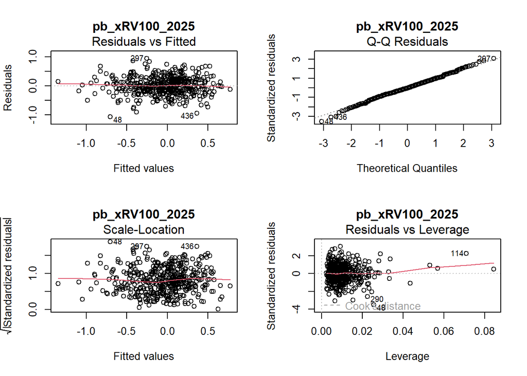

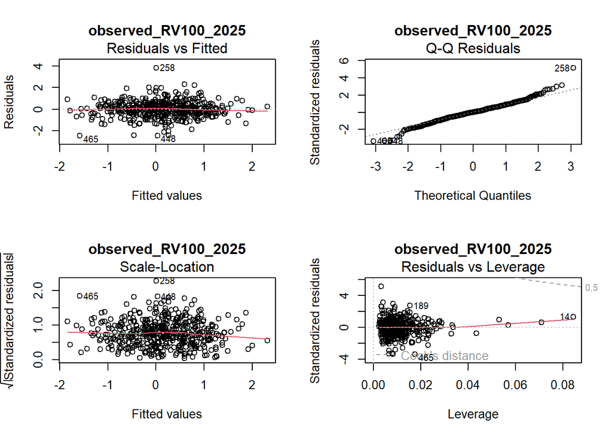

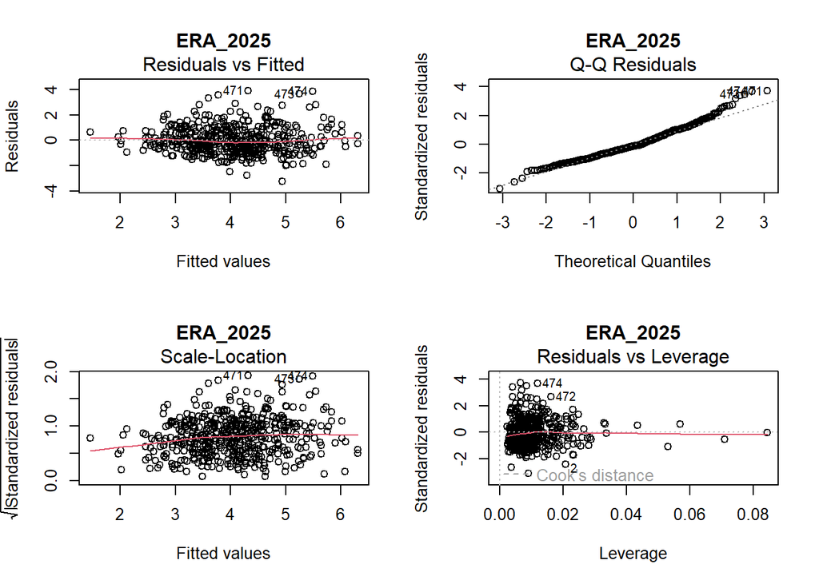

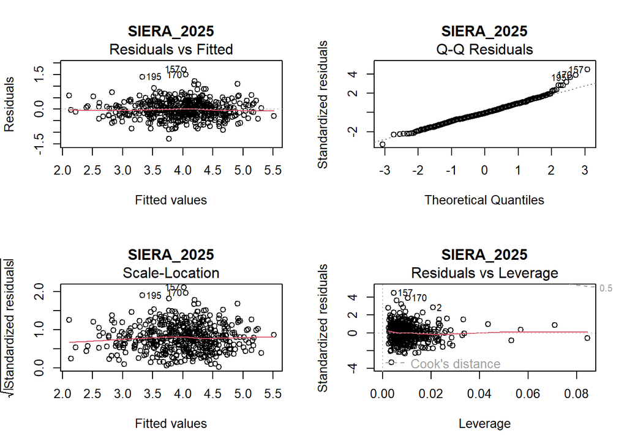

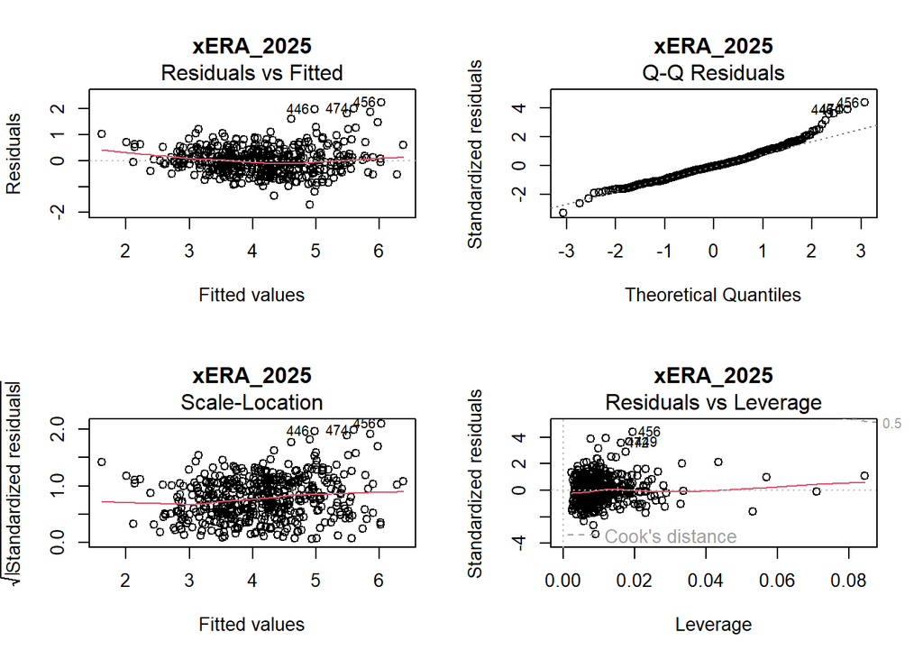

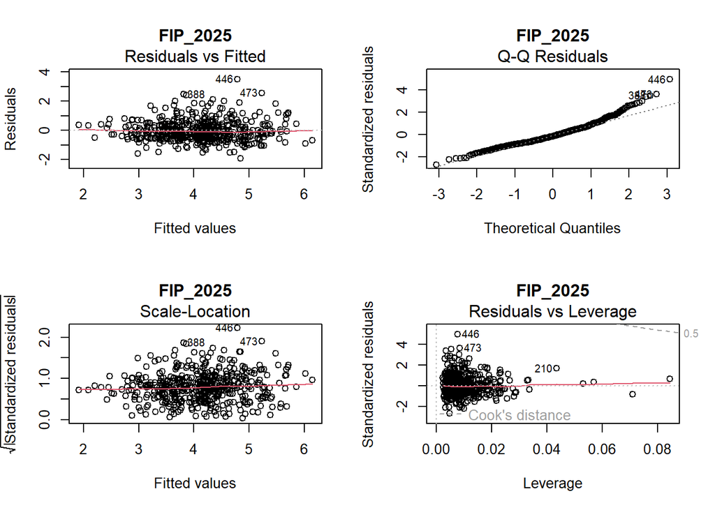

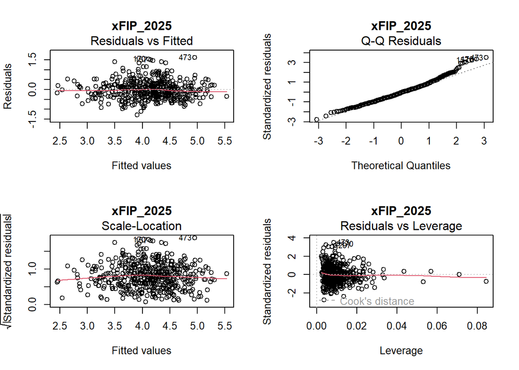

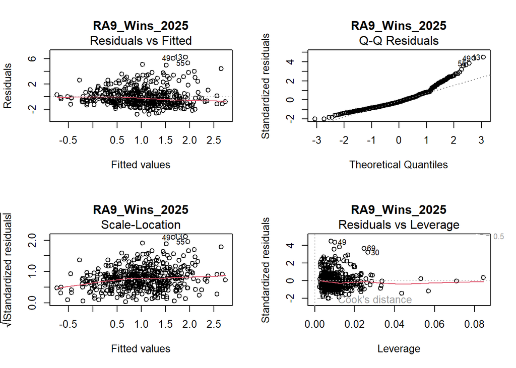

```r
for (outcome in outcomes_2025) {

  model_formula <- reformulate(
    termlabels = c(
      "z_stuff",
      "z_command",
      "z_miss",
      "z_contact"
    ),
    response = outcome
  )

  model <- lm(
    model_formula,
    data = CDI_outcomes_2025_2026
  )

  par(mfrow = c(2, 2))

  plot(
    model,
    main = outcome
  )

  par(mfrow = c(1, 1))
}
```

## Testing the 5 subjects that stand out in Leverage

```r
# Leverage values
lev <- hatvalues(era_lm)

# Top 10 highest leverage observations
head(sort(lev, decreasing = TRUE), 10)
```

```
##         14        114        193        123        210         59         23
## 0.08446697 0.07109780 0.05694586 0.05305009 0.04343483 0.03377393 0.03339885
##        142         18        237
## 0.03297671 0.02883563 0.02845966
```

```r
CDI_outcomes_2025_2026 %>%
  mutate(
    leverage = hatvalues(era_lm)
  ) %>%
  arrange(desc(leverage)) %>%
  select(pitcher_name,
         leverage,
         z_stuff,
         z_command,
         z_miss,
         z_contact,
         ERA_2025) %>%
  head(5)
```

```
## # A tibble: 5 × 7
##   pitcher_name   leverage z_stuff z_command z_miss z_contact ERA_2025
##   <chr>             <dbl>   <dbl>     <dbl>  <dbl>     <dbl>    <dbl>
## 1 Tyler Rogers     0.0845  4.20       2.50  -0.879    3.40       1.98
## 2 Brendon Little   0.0711  0.963     -5.34   2.71     0.388      3.03
## 3 Fernando Cruz    0.0569 -0.0630    -3.12   3.83    -0.0221     3.56
## 4 Tim Hill         0.0531  2.59       2.34  -1.79     0.425      3.09
## 5 Nabil Crismatt   0.0434 -2.60       0.264  0.362    1.10       3.71
```

```r
CDI_outcomes_2025_2026 %>%
  mutate(
    leverage = hatvalues(era_lm),
    cooks = cooks.distance(era_lm)
  ) %>%
  arrange(desc(cooks)) %>%
  select(pitcher_name, leverage, cooks) %>%
  head(5)
```

```
## # A tibble: 5 × 3
##   pitcher_name     leverage  cooks
##   <chr>               <dbl>  <dbl>
## 1 Bradley Blalock   0.0119  0.0327
## 2 Erik Miller       0.0209  0.0242
## 3 George Soriano    0.0162  0.0234
## 4 Carson Palmquist  0.00848 0.0208
## 5 Jordan Romano     0.00652 0.0181
```

Five pitchers consistently exhibited elevated leverage values due to extreme combinations of the four CDI skill domains. These observations corresponded to legitimate pitcher profiles (e.g., submarine or otherwise atypical pitchers) rather than data errors. Although these pitchers occupied unusual regions of the predictor space, Cook’s Distance values remained low (maximum = 0.033), indicating that no single observation exerted undue influence on the fitted regression models. Therefore, all observations were retained for analysis.

## Bootstrap Coefficients

```r
library(boot)
```

```r
library(dplyr)
library(purrr)
library(tibble)

# Outcomes to evaluate
outcomes_2025 <- c(
  "pb_xRV100_2025",
  "observed_RV100_2025",
  "ERA_2025",
  "SIERA_2025",
  "xERA_2025",
  "FIP_2025",
  "xFIP_2025",
  "RA9_Wins_2025",
  "pb_xRV100_2026",
  "SIERA_2026",
  "xERA_2026",
  "FIP_2026",
  "xFIP_2026",
  "ERA_2026"
)

# Function that bootstraps one dependent outcome
bootstrap_skill_model <- function(outcome, data, R = 10000) {

  # Keep only complete cases for this specific model
  model_data <- data %>%
    select(
      all_of(outcome),
      z_stuff,
      z_command,
      z_miss,
      z_contact
    ) %>%
    filter(complete.cases(.))

  # Build regression formula
  model_formula <- reformulate(
    termlabels = c(
      "z_stuff",
      "z_command",
      "z_miss",
      "z_contact"
    ),
    response = outcome
  )

  # Statistic returned during each bootstrap sample
  boot_statistic <- function(data, indices) {

    sampled_data <- data[indices, ]

    model <- lm(
      model_formula,
      data = sampled_data
    )

    coef(model)
  }

  set.seed(123)

  boot_model <- boot(
    data = model_data,
    statistic = boot_statistic,
    R = R
  )

  coefficient_names <- names(
    coef(lm(model_formula, data = model_data))
  )

  # Extract percentile confidence intervals
  results <- map_dfr(
    seq_along(coefficient_names),
    function(i) {

      ci <- tryCatch(
        boot.ci(
          boot_model,
          type = "perc",
          index = i
        ),
        error = function(e) NULL
      )

      if (is.null(ci) || is.null(ci$percent)) {

        lower_ci <- NA_real_
        upper_ci <- NA_real_

      } else {

        lower_ci <- ci$percent[4]
        upper_ci <- ci$percent[5]
      }

      tibble(
        Outcome = outcome,
        N = nrow(model_data),
        Predictor = coefficient_names[i],
        Estimate = boot_model$t0[i],
        CI_Lower = lower_ci,
        CI_Upper = upper_ci
      )
    }
  )

  results
}

# Run bootstrap for every outcome
set.seed(123)

bootstrap_results_2025 <- map_dfr(
  outcomes_2025,
  bootstrap_skill_model,
  data = CDI_outcomes_2025_2026,
  R = 10000
)

bootstrap_results_2025
```

```
## # A tibble: 70 × 6
##    Outcome                 N Predictor   Estimate CI_Lower CI_Upper
##    <chr>               <int> <chr>          <dbl>    <dbl>    <dbl>
##  1 pb_xRV100_2025        474 (Intercept) -0.0412   -0.0700  -0.0135
##  2 pb_xRV100_2025        474 z_stuff     -0.223    -0.266   -0.182
##  3 pb_xRV100_2025        474 z_command   -0.171    -0.200   -0.141
##  4 pb_xRV100_2025        474 z_miss      -0.0674   -0.101   -0.0344
##  5 pb_xRV100_2025        474 z_contact   -0.00185  -0.0329   0.0294
##  6 observed_RV100_2025   474 (Intercept)  0.145     0.0771   0.212
##  7 observed_RV100_2025   474 z_stuff     -0.0656   -0.166    0.0268
##  8 observed_RV100_2025   474 z_command    0.226     0.163    0.294
##  9 observed_RV100_2025   474 z_miss       0.427     0.343    0.517
## 10 observed_RV100_2025   474 z_contact    0.478     0.409    0.549
## # ℹ 60 more rows
```

```r
bootstrap_skills_2025_2026 <- bootstrap_results_2025 %>%
  filter(Predictor != "(Intercept)") %>%
  mutate(
    across(
      c(Estimate, CI_Lower, CI_Upper),
      ~ round(.x, 3)
    ),
    Significant = case_when(
      CI_Lower > 0 & CI_Upper > 0 ~ "Positive",
      CI_Lower < 0 & CI_Upper < 0 ~ "Negative",
      TRUE ~ "Includes zero"
    )
  )

bootstrap_skills_2025_2026
```

```
## # A tibble: 56 × 7
##    Outcome                 N Predictor Estimate CI_Lower CI_Upper Significant
##    <chr>               <int> <chr>        <dbl>    <dbl>    <dbl> <chr>
##  1 pb_xRV100_2025        474 z_stuff     -0.223   -0.266   -0.182 Negative
##  2 pb_xRV100_2025        474 z_command   -0.171   -0.2     -0.141 Negative
##  3 pb_xRV100_2025        474 z_miss      -0.067   -0.101   -0.034 Negative
##  4 pb_xRV100_2025        474 z_contact   -0.002   -0.033    0.029 Includes zero
##  5 observed_RV100_2025   474 z_stuff     -0.066   -0.166    0.027 Includes zero
##  6 observed_RV100_2025   474 z_command    0.226    0.163    0.294 Positive
##  7 observed_RV100_2025   474 z_miss       0.427    0.343    0.517 Positive
##  8 observed_RV100_2025   474 z_contact    0.478    0.409    0.549 Positive
##  9 ERA_2025              474 z_stuff      0.012   -0.105    0.136 Includes zero
## 10 ERA_2025              474 z_command   -0.175   -0.273   -0.081 Negative
## # ℹ 46 more rows
```

```r
bootstrap_skills_2025_2026 %>%
  filter(Significant != "Includes zero")
```

```
## # A tibble: 37 × 7
##    Outcome                 N Predictor Estimate CI_Lower CI_Upper Significant
##    <chr>               <int> <chr>        <dbl>    <dbl>    <dbl> <chr>
##  1 pb_xRV100_2025        474 z_stuff     -0.223   -0.266   -0.182 Negative
##  2 pb_xRV100_2025        474 z_command   -0.171   -0.2     -0.141 Negative
##  3 pb_xRV100_2025        474 z_miss      -0.067   -0.101   -0.034 Negative
##  4 observed_RV100_2025   474 z_command    0.226    0.163    0.294 Positive
##  5 observed_RV100_2025   474 z_miss       0.427    0.343    0.517 Positive
##  6 observed_RV100_2025   474 z_contact    0.478    0.409    0.549 Positive
##  7 ERA_2025              474 z_command   -0.175   -0.273   -0.081 Negative
##  8 ERA_2025              474 z_miss      -0.438   -0.558   -0.321 Negative
##  9 ERA_2025              474 z_contact   -0.592   -0.699   -0.489 Negative
## 10 SIERA_2025            474 z_stuff     -0.152   -0.195   -0.104 Negative
## # ℹ 27 more rows
```

```r
bootstrap_skills_wide <- bootstrap_skills_2025_2026 %>%
  mutate(
    Estimate_CI = paste0(
      Estimate,
      " [",
      CI_Lower,
      ", ",
      CI_Upper,
      "]"
    )
  ) %>%
  select(
    Outcome,
    Predictor,
    Estimate_CI
  ) %>%
  tidyr::pivot_wider(
    names_from = Predictor,
    values_from = Estimate_CI
  )

bootstrap_skills_wide
```

```
## # A tibble: 14 × 5
##    Outcome             z_stuff                 z_command        z_miss z_contact
##    <chr>               <chr>                   <chr>            <chr>  <chr>
##  1 pb_xRV100_2025      -0.223 [-0.266, -0.182] -0.171 [-0.2, -… -0.06… -0.002 […
##  2 observed_RV100_2025 -0.066 [-0.166, 0.027]  0.226 [0.163, 0… 0.427… 0.478 [0…
##  3 ERA_2025            0.012 [-0.105, 0.136]   -0.175 [-0.273,… -0.43… -0.592 […
##  4 SIERA_2025          -0.152 [-0.195, -0.104] -0.137 [-0.172,… -0.43… -0.083 […
##  5 xERA_2025           -0.063 [-0.127, 0.002]  -0.138 [-0.185,… -0.43… -0.519 […
##  6 FIP_2025            -0.077 [-0.155, 0.006]  -0.148 [-0.205,… -0.43… -0.399 […
##  7 xFIP_2025           -0.119 [-0.171, -0.064] -0.093 [-0.132,… -0.40… -0.095 […
##  8 RA9_Wins_2025       -0.168 [-0.335, -0.011] 0.263 [0.117, 0… 0.463… 0.395 [0…
##  9 pb_xRV100_2026      -0.209 [-0.273, -0.147] -0.097 [-0.146,… -0.01… -0.032 […
## 10 SIERA_2026          -0.273 [-0.387, -0.168] -0.002 [-0.093,… -0.16… -0.065 […
## 11 xERA_2026           -0.247 [-0.512, 0.037]  -0.122 [-0.379,… -0.56… -0.253 […
## 12 FIP_2026            -0.381 [-0.619, -0.161] -0.026 [-0.381,… -0.38… -0.127 […
## 13 xFIP_2026           -0.25 [-0.384, -0.121]  0.043 [-0.1, 0.… -0.23… -0.087 […
## 14 ERA_2026            -0.354 [-0.802, 0.026]  0.141 [-0.606, … -0.66… -0.292 […
```

Bootstrap confidence intervals largely confirmed the original regression results, indicating that the relationships between the CDI skill domains and run-prevention outcomes were stable under repeated resampling, with reduced precision observed only for a small number of weaker predictor-outcome combinations.